# HW4

Renjie Liu

4/25/2021

### Question 1:

Combine the data from the 16 files into a single dataset and plot it.

```r
library(fpp)
library(TSA)
```

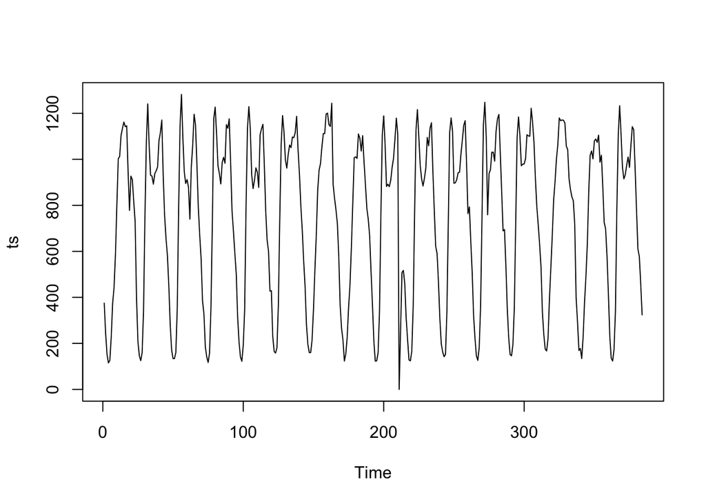

```r
# Manually combine the excel file into one cxv file
traffic <- read.csv('traffic.csv')

ts <- ts(traffic$Exit, frequency = 1)
plot(ts)
```

### Question 2: Split the dataset into a training dataset which includes 6/16/2013 - 6/30/2013 samples and a test dataset which includes 7/1/2013 samples and plot the ACF and PACF.

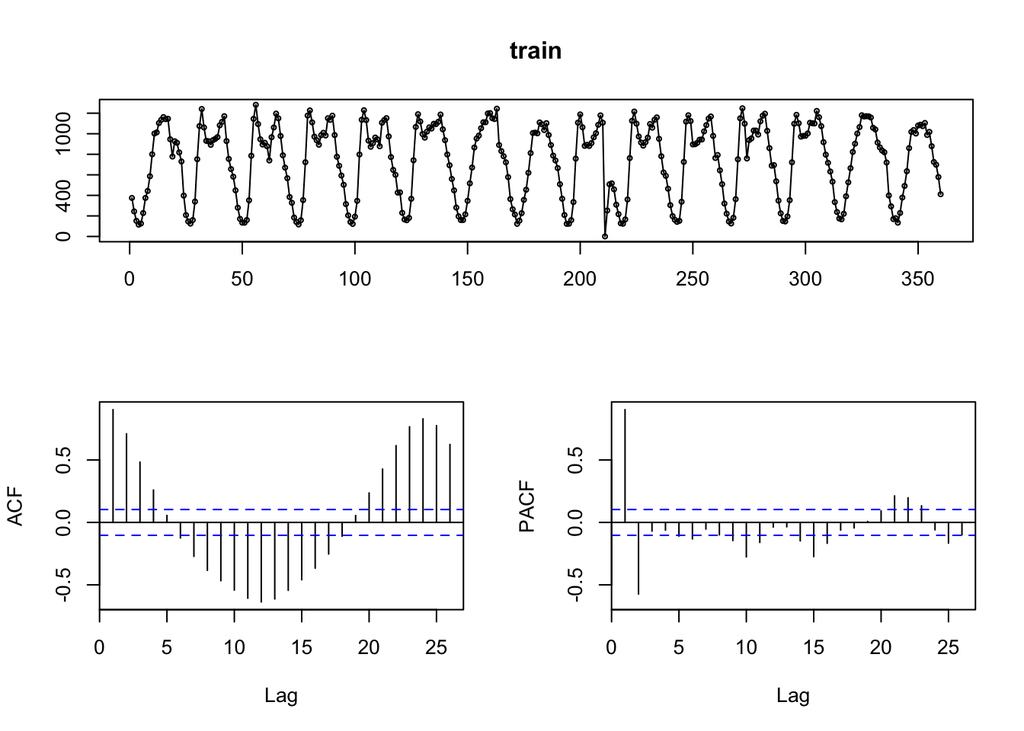

```r
library(forecast)
train <- ts(traffic$Exit[1:360], frequency = 1)
test <- ts(traffic$Exit[361:384], frequency = 1)

tsdisplay(train)
```

In the train plot. The ACF plot is sinusoidal, and the PACF has a cutoff after 2 lags. This indicated a non seasonal of AR2.

### Question 3:

Build an 𝐴𝑅𝐼𝑀𝐴(𝑝,𝑑,𝑞) model using the training dataset and R auto.arima() function. Change the values of 𝑝 and 𝑞 and determine the best model using AICc and BIC values. Do AICc and BIC select the same model as the best model? For each derived model, review the residual plots for the residuals ACF and normality.

```r
auto <- auto.arima(train, stepwise = FALSE, approximation = FALSE,seasonal = FALSE)
auto
```

```
## Series: train
## ARIMA(2,0,3) with non-zero mean
##
## Coefficients:
##          ar1      ar2      ma1      ma2      ma3      mean
##       1.8088  -0.8853  -0.5348  -0.2671  -0.1157  746.3181
## s.e.  0.0288   0.0287   0.0600   0.0596   0.0654    6.8586
##
## sigma^2 estimated as 13443:  log likelihood=-2220.78
## AIC=4455.56   AICc=4455.88   BIC=4482.77
```

```r
a1 <- Arima(train, order = c(2,0,0))
a1
```

```
## Series: train
## ARIMA(2,0,0) with non-zero mean
##
## Coefficients:
##          ar1      ar2      mean
##       1.4390  -0.5890  739.0216
## s.e.  0.0425   0.0426   43.0839
##
## sigma^2 estimated as 15307:  log likelihood=-2245.08
## AIC=4498.16   AICc=4498.28   BIC=4513.71
```

```r
a2 <- Arima(train, order = c(2,0,4))
a2
```

```
## Series: train
## ARIMA(2,0,4) with non-zero mean
##
## Coefficients:
##          ar1      ar2      ma1      ma2      ma3     ma4      mean
##       1.8479  -0.9224  -0.6164  -0.2987  -0.1278  0.1245  746.3450
## s.e.  0.0403   0.0384   0.0954   0.0737   0.0662  0.1098    6.8877
##
## sigma^2 estimated as 13408:  log likelihood=-2219.88
## AIC=4455.75   AICc=4456.16   BIC=4486.84
```

```r
a3 <- Arima(train, order = c(2,0,1))
a3
```

```
## Series: train
## ARIMA(2,0,1) with non-zero mean
##
## Coefficients:
##          ar1      ar2      ma1      mean
##       1.5254  -0.6671  -0.1343  740.0717
## s.e.  0.0776   0.0714   0.1109   39.4450
##
## sigma^2 estimated as 15282:  log likelihood=-2244.29
## AIC=4498.59   AICc=4498.76   BIC=4518.02
```

```r
a4 <- Arima(train, order = c(1,0,3))
a4
```

```
## Series: train
## ARIMA(1,0,3) with non-zero mean
##
## Coefficients:
##          ar1     ma1     ma2     ma3      mean
##       0.7131  0.7151  0.4540  0.1921  735.2137
## s.e.  0.0529  0.0686  0.0782  0.0644   53.5991
##
## sigma^2 estimated as 15765:  log likelihood=-2249.36
## AIC=4510.72   AICc=4510.96   BIC=4534.03
```

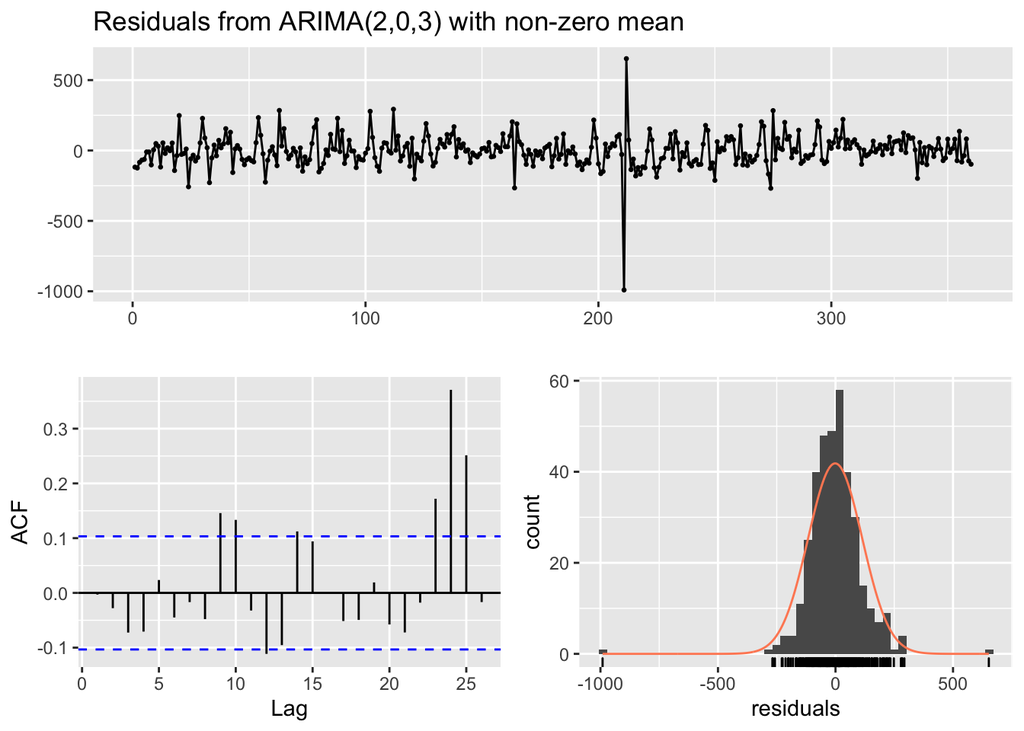

```
##
##  Ljung-Box test
##
## data:  Residuals from ARIMA(2,0,3) with non-zero mean
## Q* = 20.439, df = 4, p-value = 0.0004089
##
## Model df: 6.   Total lags used: 10
```

```r
checkresiduals(auto)
```

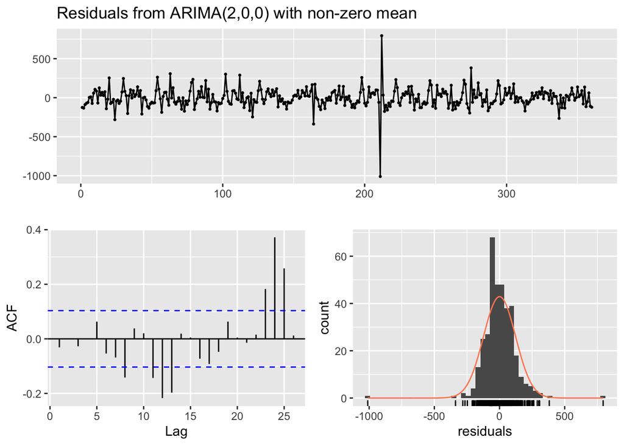

```
##
##  Ljung-Box test
##
## data:  Residuals from ARIMA(2,0,0) with non-zero mean
## Q* = 12.992, df = 7, p-value = 0.07231
##
## Model df: 3.   Total lags used: 10
```

```r
checkresiduals(a1)
```

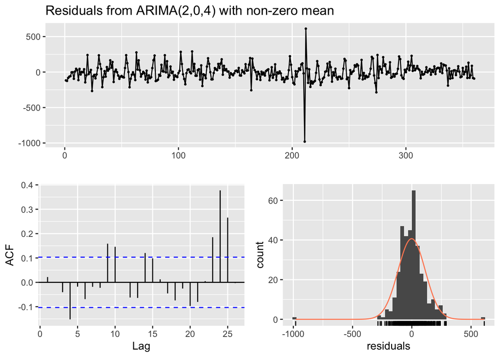

```
##
##  Ljung-Box test
##
## data:  Residuals from ARIMA(2,0,4) with non-zero mean
## Q* = 28.658, df = 3, p-value = 2.642e-06
##
## Model df: 7.   Total lags used: 10
```

```r
checkresiduals(a2)
```

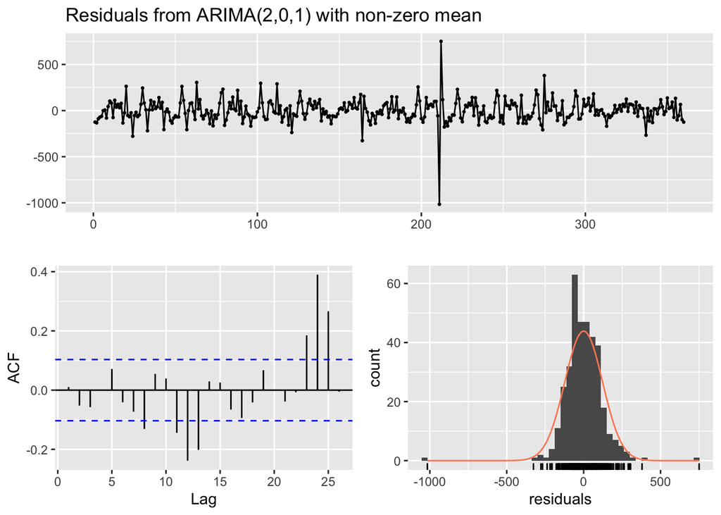

```
##
##  Ljung-Box test
##
## data:  Residuals from ARIMA(2,0,1) with non-zero mean
## Q* = 14.715, df = 6, p-value = 0.02259
##
## Model df: 4.   Total lags used: 10
```

```r
checkresiduals(a3)
```

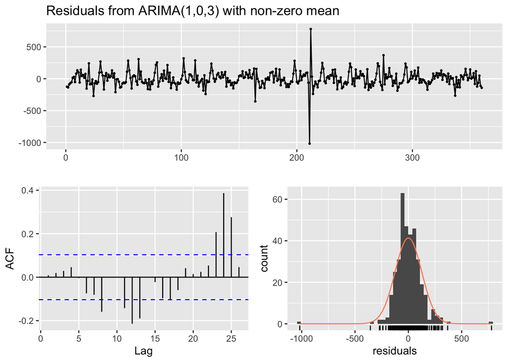

```
##
##  Ljung-Box test
##
## data:  Residuals from ARIMA(1,0,3) with non-zero mean
## Q* = 15.073, df = 5, p-value = 0.01005
##
## Model df: 5.   Total lags used: 10
```

```r
checkresiduals(a4)
```

```r
shapiro.test(auto$residuals)
```

```
##
##  Shapiro-Wilk normality test
##
## data:  auto$residuals
## W = 0.87428, p-value < 2.2e-16
```

```r
shapiro.test(a1$residuals)
```

```
##
##  Shapiro-Wilk normality test
##
## data:  a1$residuals
## W = 0.87053, p-value < 2.2e-16
```

```r
shapiro.test(a2$residuals)
```

```
##
##  Shapiro-Wilk normality test
##
## data:  a2$residuals
## W = 0.87995, p-value = 3.828e-16
```

```r
shapiro.test(a3$residuals)
```

```
##
##  Shapiro-Wilk normality test
##
## data:  a3$residuals
## W = 0.87759, p-value = 2.622e-16
```

```r
shapiro.test(a4$residuals)
```

```
##
##  Shapiro-Wilk normality test
##
## data:  a4$residuals
## W = 0.87369, p-value < 2.2e-16
```

### Question 4:

Build a day of the week seasonal 𝐴𝑅𝐼𝑀𝐴(𝑝,𝑑,𝑞)(𝑃,𝑄,𝐷)𝑠 model using the training dataset and R auto.arima() function.

```r
train1 <- ts(traffic$Exit[1:360], frequency = 7*24)
auto2<- auto.arima(train1, stepwise = FALSE, approximation = FALSE, seasonal = TRUE)
auto2
```

```
## Series: train1
## ARIMA(0,1,2)(0,1,0)[168]
##
## Coefficients:
##           ma1      ma2
##       -0.4741  -0.4853
## s.e.   0.0593   0.0586
##
## sigma^2 estimated as 7081:  log likelihood=-1121.66
## AIC=2249.31   AICc=2249.44   BIC=2259.07
```

From the auto arima, the best model is seasonal with first order differencing, and first order differencing with ma2 for the non seasonal part.

### Question 5:

Use the 𝐴𝑅𝐼𝑀𝐴(𝑝,𝑑,𝑞)(𝑃,𝑄,𝐷)𝑠 model from Question 4 to forecast for July 1st (which is a Monday). Plot your result.

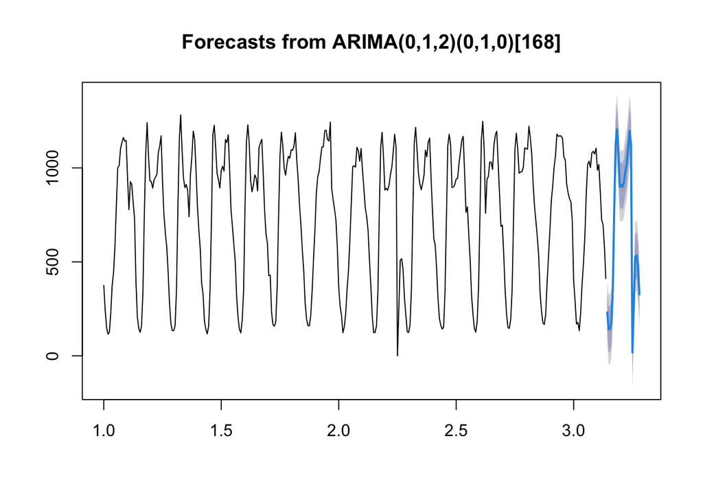

```r
fore1 <- forecast(auto2,h=24,level = c(80, 95))
plot(fore1)
```

### Question 6:

Build a hour of the day seasonal 𝐴𝑅𝐼𝑀𝐴(𝑝,𝑑,𝑞)(𝑃,𝑄,𝐷)𝑠model using the training dataset and R auto.arima() function.

```r
train1 <- ts(traffic$Exit[1:360], frequency = 24)
auto3<- auto.arima(train1, stepwise = FALSE, approximation = FALSE, seasonal = TRUE)
auto3
```

```
## Series: train1
## ARIMA(2,0,1)(2,1,0)[24]
##
## Coefficients:
##          ar1      ar2      ma1     sar1     sar2
##       1.4028  -0.6068  -0.4877  -0.4156  -0.3241
## s.e.  0.1444   0.1021   0.1751   0.0561   0.0530
##
## sigma^2 estimated as 11305:  log likelihood=-2046.63
## AIC=4105.25   AICc=4105.51   BIC=4128.16
```

From the auto arima, the best model is seasonal with first order differencing with AR2, and AR2 with MA1 with no differencing for the non seasonal part.

### Question 7:

Use the 𝐴𝑅𝐼𝑀𝐴(𝑝,𝑑,𝑞)(𝑃,𝑄,𝐷)𝑠 model from Question 6 to forecast for July 1st (which is a Monday). Plot your result.

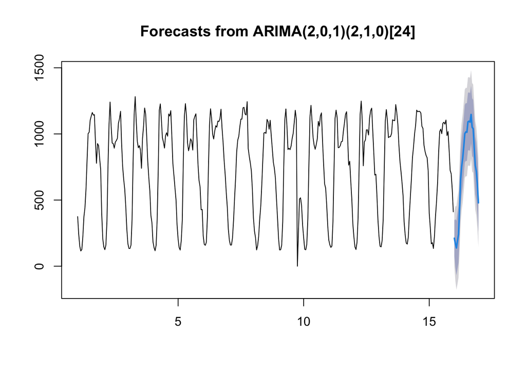

```r
fore2 <- forecast(auto3,h=24,level = c(80, 95))
plot(fore2)
```

### Question 8:

Compare the forecast of the models from Questions 5 and 7 for July 1 8:00, 9:00, 17:00 and 18:00, which model is better (Questions 4 or 6)?

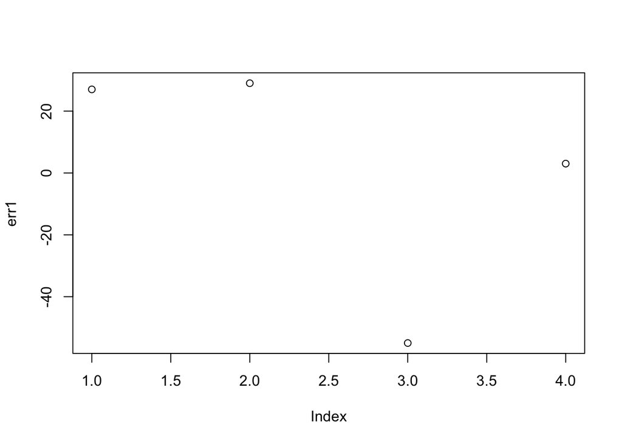

```r
f1 <- fore1$mean[c(8,9,17,18)]
f2 <- fore2$mean[c(8,9,17,18)]

actual <- traffic$Exit[c(368,369,377,378)]

err1 <- actual - f1
err2 <- actual - f2

plot(err1)
```

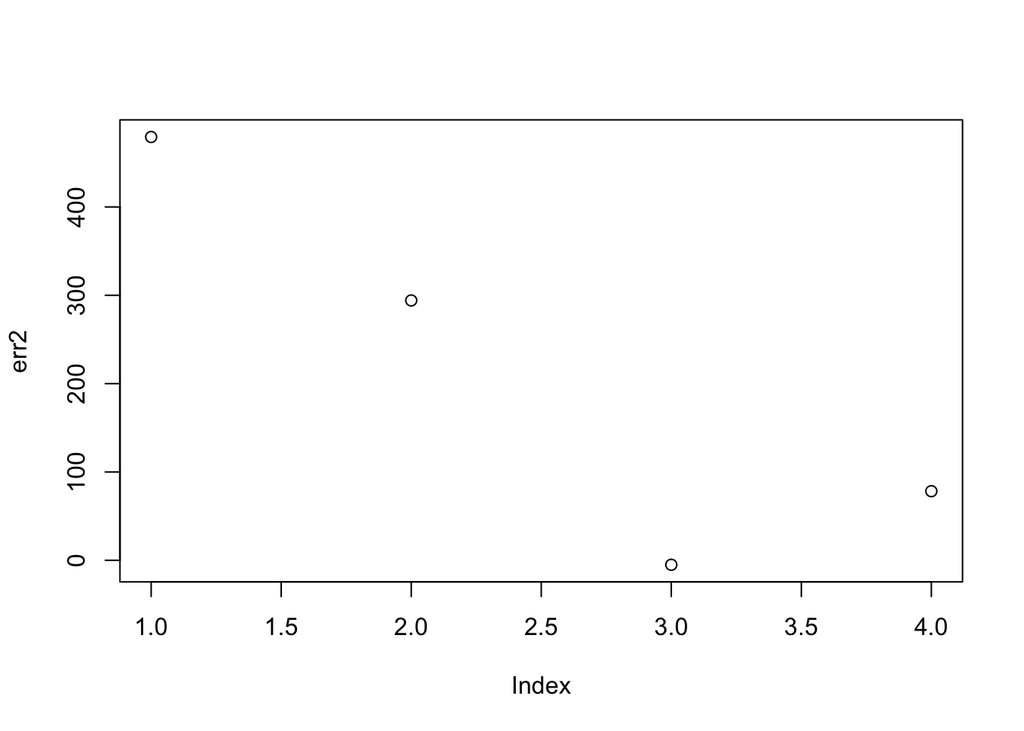

```r
plot(err2)
```

```r
sum((err1)^2)
```

```
## [1] 4604.173
```

```r
sum((err2)^2)
```

```
## [1] 322268.9
```